# GSTools: The Python toolbox for your geo-statistical project!

## Sebastian Müller, Lennart Schüler, Alraune Zech, Sabine Attinger and Falk Heße

*To navigate through the presentation, use the arrows in the lower right corner or your arrow-keys (**right* *→ next section;* *down* *→ go through current section)*

## Motivation

Geo-scientific model development is lacking comprehensive open source tools, that provide state-of-the art geo-statistic methods. To bridge this gap, we developed a geo-statistical toolbox named GeoStatTools (GSTools), which is a Python package providing an abundance of methods in a modern easy-to-use approach.

## Purpose

GeoStatTools provides geostatistical tools for various purposes:

- random field generation
- conditioned field generation
- incompressible random vector field generation
- simple and ordinary kriging
- variogram estimation and fitting
- many readily provided and even user-defined covariance models
- plotting and exporting routines

## Installation

You can install gstools via `pip` *or* `conda`:

```
pip install gstools  /  conda install gstools
```

[figure not shown]

## Content

In the following, we will show a handful of tutorials to demonstrate the capabilites described above.

- Tutorial 1: Random Field Generation
- Tutorial 2: The Covariance Model
- Tutorial 3: Variogram Estimation
- Tutorial 4: Kriging
- Tutorial 5: Conditioned Fields
- Tutorial 6: Field transformations

```python
import warnings
warnings.filterwarnings('ignore')
```

# Tutorial 1: Random Field Generation

The main feature of GSTools is the spatial random field generator [`SRF`](https://geostat-framework.readthedocs.io/projects/gstools/en/stable/field.html#gstools.field.SRF), which can generate random fields following a given covariance model. The generator provides a lot of nice features, which will be explained in the following.

GSTools generates spatial random fields with a given covariance model or a semi-variogram. This is done by using the so-called randomization method. The spatial random field is represented by a stochastic Fourier integral and its discretized modes are evaluated at random frequencies.

GSTools supports arbitrary and non-isotropic covariance models.

## A Very Simple Example

We are going to start with a very simple example of a spatial random field with an isotropic Gaussian covariance model and following parameters:

- variance $\sigma^2=1$
- correlation length $\ell=10$

First, we set things up and create the axes for the field. We are going to need the SRF class for the actual generation of the spatial random field. But SRF also needs a covariance model and we will simply take the Gaussian model.

```python
import gstools as gs

x = y = range(100)
```

Now we create the covariance model with the parameters $\sigma^2$ and $\ell$ and hand it over to `SRF`. By specifying a seed, we make sure to create reproducible results:

```python
model = gs.Gaussian(dim=2, var=1, len_scale=10)
srf = gs.SRF(model, seed=20170519)
```

With these simple steps, everything is ready to create our first random field. We will create the field on a structured grid (as you might have guessed from the x and y), which makes it easier to plot.

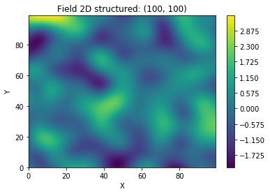

```python
field = srf.structured([x, y])
srf.plot()
```

## Creating Fancier Fields

Only using Gaussian covariance fields gets boring. Now we are going to create much rougher random fields by using an exponential covariance model and we are going to make them anisotropic.

The code is very similar to the previous examples, but with a different covariance model class Exponential. As model parameters we a using following

- variance $\sigma^2=1$
- correlation lengths $\ell=(12, 3)$
- rotation angle $\theta=\pi/8$

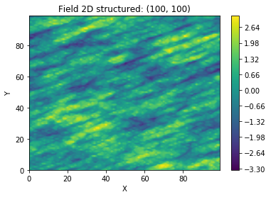

```python
import numpy as np
x = y = np.arange(100)
model = gs.Exponential(dim=2, var=1, len_scale=[12.0, 3.0], angles=np.pi / 8)
srf = gs.SRF(model, seed=20170519)
srf.structured([x, y])
srf.plot()
```

# Tutorial 2: The Covariance Model

One of the core-features of GSTools is the powerful [`CovModel`](https://geostat-framework.readthedocs.io/projects/gstools/en/stable/generated/gstools.covmodel.CovModel.html#gstools.covmodel.CovModel) class, which allows you to define covariance models. The resulting models provide a lot of functionality and can be used for **random field generation**, **variogram fitting** and **kriging**.

A covariance model is used to characterize the semi-variogram, denoted by $\gamma$, of a spatial random field. In GSTools, we use the following formulation for an isotropic and stationary field:

$$\gamma\left(r\right)= \sigma^2\cdot\left(1-\mathrm{cor}\left(\frac{r}{\ell}\right)\right)+n$$

Where:

- $\mathrm{cor}(h)$ is the normalized correlation function taking the non-dimensional distance $h=\frac{r}{\ell}$ (*Rubin 2003*)
- $\sigma^2$ is the variance
- $n$ is the nugget (subscale variance)
- $\ell$ is the main length-scale

## Provided Covariance Models

Here's an excerpt of the covariance models provided by GSTools:

| Name | Description | $\mathrm{cor}(h)$ |
| --- | --- | --- |
| `Gaussian` | The Gaussian covariance model | $\exp\left(- \frac{\pi}{4} \cdot h^2\right)$ |
| `Exponential` | The Exponential covariance model. | $\exp(-h)$ |
| `Matern` | The Matérn covariance model. | $\frac{\left(\sqrt{\nu}\cdot h\right)^{\nu}}{2^{\nu-1}\cdot\Gamma\left(\nu\right)} \cdot \mathrm{K}_{\nu}\left(\sqrt{\nu}\cdot h\right)$ |
| `Stable` | The stable covariance model. | $\exp(-h^{\alpha})$ |
| `Rational` | The rational quadratic covariance model. | $\left(1 + \frac{h^2}{2\alpha}\right)^{-\alpha}$ |
| `Spherical` | The Spherical covariance model. | $1-\frac{3}{2} h + \frac{1}{2} h^3 \; (h<1)$ |

## Basic Methods

The covariance model class of GSTools provides the following basic methods:

- `CovModel.variogram`: The variogram
- `CovModel.covariance`: The (auto-)covariance
- `CovModel.correlation`: The (auto-)correlation

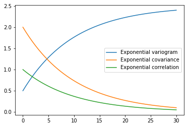

```python
model = gs.Exponential(dim=3, var=2.0, len_scale=10, nugget=0.5)
ax = model.plot("variogram")
model.plot("covariance", ax=ax)
model.plot("correlation", ax=ax)
```

## Anisotropy and Rotation

In 2D and 3D you can specify rotation angles and anisotropy ratios to the `CovModel`. To explore the resulting spatial variogram, GSTools provides some convenient functions.

**Note:** The basic variogram methods given above always depend on the isotropified distances.

```
Anisotropy representations:
Anisotropy ratios: [0.5 0.4]
Main length scale: 10
All length scales: [10.  5.  4.]
Rotation angles: [2.5 0.  0. ]
```

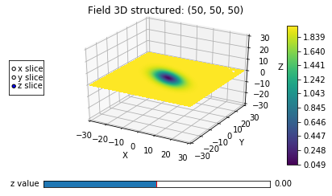

```python
model = gs.Gaussian(dim=3, var=2.0, len_scale=[10, 5, 4], angles=2.5)
model.plot("vario_spatial")
print("Anisotropy representations:")
print("Anisotropy ratios:", model.anis)
print("Main length scale:", model.len_scale)
print("All length scales:", model.len_scale_vec)
print("Rotation angles:", model.angles)
```

## Spectral methods

The spectrum of a covariance model is given by:

$$S(\mathbf{k}) = \left(\frac{1}{2\pi}\right)^n \int C(\Vert\mathbf{r}\Vert) e^{i b\mathbf{k}\cdot\mathbf{r}} d^n\mathbf{r}$$

Since the covariance function $C(r)$ is radially symmetric, we can calculate this by the hankel-transformation:

$$S(k) = \left(\frac{1}{2\pi}\right)^n \cdot \frac{(2\pi)^{n/2}}{(bk)^{n/2-1}} \int_0^\infty r^{n/2-1} C(r) J_{n/2-1}(bkr) r dr$$

Where $k=\left\Vert\mathbf{k}\right\Vert$.

Depending on the spectrum, the spectral-density is defined by:

$$\tilde{S}(k) = \frac{S(k)}{\sigma^2}$$

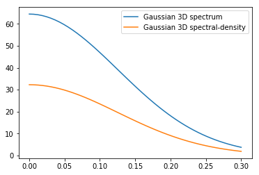

```python
#You can access these methods in the following way
model = gs.Gaussian(dim=3, var=2.0, len_scale=10)
ax = model.plot("spectrum")
model.plot("spectral_density", ax=ax)
```

## Different length scales

Besides the given length-scale, there are many other ways of characterizing a certain scale of a covariance model. We provide two common scales with the covariance model.

- **Integral scale**: $$I = \int_0^\infty \rho(r) dr$$
- **Percentile scale**: The distance, where the normalized variogram reaches a certain percentage of its (partial-)sill. This ignores the nugget.

```
90% Percentile scale: 17.437215135964117
Integral/Length scale: (9.027452929509336, 10)
```

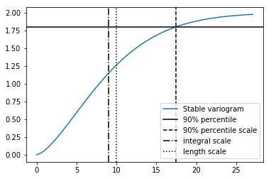

```python
model = gs.Stable(dim=3, var=2.0, len_scale=10)
per_scale = model.percentile_scale(0.9)
int_scale, len_scale = model.integral_scale, model.len_scale
print("90% Percentile scale:", per_scale)
print("Integral/Length scale:", (int_scale, len_scale))
ax = model.plot()
ax.axhline(1.8, color="k", label=r"90% percentile")
ax.axvline(per_scale, color="k", linestyle="--", label=r"90% percentile scale")
ax.axvline(int_scale, color="k", linestyle="-.", label=r"integral scale")
ax.axvline(len_scale, color="k", linestyle=":", label=r"length scale")
ax.legend()
```

# Tutorial 3: Variogram Estimation

Estimating and fitting the spatial correlations is an important part of geostatistics. These spatial correlations can be expressed by the variogram, which can be estimated with the subpackage gstools.variogram. The variograms can be estimated on structured and unstructured grids.

## Fit an estimated Variogram

Here we estimate the variogram of a synthetic field with an exponential model and eventually fit a stable model to it.

We use the following parameters:

- dimension $d=2$
- variance $\sigma^2=2$
- correlation length $\ell=8$

### Creation of the synthetic field

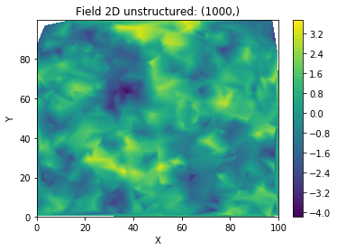

```python
x = np.random.RandomState(19970221).rand(1000) * 100.0
y = np.random.RandomState(20011012).rand(1000) * 100.0
model = gs.Exponential(dim=2, var=2, len_scale=8)
srf = gs.SRF(model, mean=0, seed=19970221)
field = srf((x, y))
srf.plot()
```

### Estimaton and fitting

```
Stable(dim=2, var=1.9235070214339676, len_scale=8.151159627793442, nugget=0.0, anis=[1.], angles=[0.], alpha=1.0517946776379135)
```

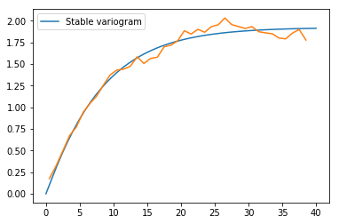

```python
# Estimate the variogram of the field with 40 bins.
bins = np.arange(40)
bin_center, gamma = gs.vario_estimate_unstructured((x, y), field, bins)
# Fit the variogram with a stable model (no nugget fitted).
fit_model = gs.Stable(dim=2)
fit_model.fit_variogram(bin_center, gamma, nugget=False)
ax = fit_model.plot(x_max=40)
ax.plot(bin_center, gamma, label="empirical variogram")
print(fit_model)
```

# Tutorial 4: Kriging

The subpackage `gstools.krige` provides routines for Gaussian process regression, also known as kriging. Kriging is a method of data interpolation based on predefined covariance models.

The aim of kriging is to derive the value of a field at some point $x_0$, when there are fixed observed values $z(x_1)\ldots z(x_n)$ at given points $x_i$.

The resluting value z_0 at x_0 is calculated as a weighted mean:

$$z_0 = \sum_{i=1}^n w_i \cdot z_i$$

The weights $W = (w_1,\ldots,w_n)$ depent on the given covariance model and the location of the target point.

The different kriging approaches provide different ways of calculating $W$.

## Provided Kriging Methods

The following kriging methods are provided within the submodule `gstools.krige`.

| Name | Description | Properties |
| --- | --- | --- |
| `Simple` | Simple kriging. | Given mean. |
| `Ordinary` | Ordinary kriging. | Estimated mean. |
| `Universal` | Universal kriging. | Functional trend. |
| `ExtDrift` | External drift kriging (EDK) | Given trend. |
| `Detrended` | Detrended simple kriging. | Used for regression kriging. |

## Comparing simple and ordinary kriging

Here we demonstrate the differences between simple (given mean 1) and ordinary (estimated mean) kriging with a simple 1D example involving 5 conditional points:

```
cond_pos = [0.3, 1.9, 1.1, 3.3, 4.7]
cond_val = [0.47, 0.56, 0.74, 1.47, 1.74]
```

```python
cond_pos = [0.3, 1.9, 1.1, 3.3, 4.7]
cond_val = [0.47, 0.56, 0.74, 1.47, 1.74]
```

```python
import matplotlib.pyplot as plt
```

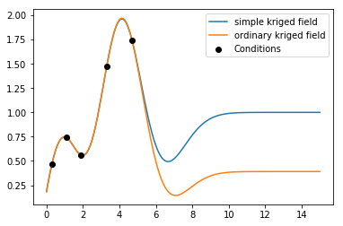

```python
gridx = np.linspace(0.0, 15.0, 151)
model = gs.Gaussian(dim=1, var=0.5, len_scale=2)
kr1 = gs.krige.Simple(model=model, mean=1, cond_pos=cond_pos, cond_val=cond_val)
kr2 = gs.krige.Ordinary(model=model, cond_pos=cond_pos, cond_val=cond_val)
kr1(gridx)
kr2(gridx)
plt.plot(gridx, kr1.field, label="simple kriged field")
plt.plot(gridx, kr2.field, label="ordinary kriged field")
plt.scatter(cond_pos, cond_val, color="k", zorder=10, label="Conditions")
plt.legend()
plt.show()
```

## Universal kriging

Universal kriging is used to automatically estimate an internal regional drift, that is specified by a number of drift functions depending on the spatial positions.

In the following we will generate a kriging field involving a linear trend in 1D.

```python
# synthetic condtions with a drift
drift_model = gs.Gaussian(dim=1, var=0.1, len_scale=2)
drift = gs.SRF(drift_model, seed=101)
cond_pos = np.linspace(0.1, 8, 10)
cond_val = drift(cond_pos) + cond_pos * 0.1 + 1
# resulting grid
gridx = np.linspace(0.0, 15.0, 151)
drift_field = drift(gridx) + gridx * 0.1 + 1
```

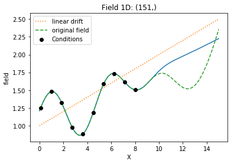

```python
model = gs.Gaussian(dim=1, var=0.1, len_scale=2)
krig = gs.krige.Universal(model, cond_pos, cond_val, "linear")
krig(gridx)
ax = krig.plot()
ax.scatter(cond_pos, cond_val, color="k", zorder=10, label="Conditions")
ax.plot(gridx, gridx * 0.1 + 1, ":", label="linear drift")
ax.plot(gridx, drift_field, "--", label="original field")
ax.legend()
```

# Tutorial 5: Conditioned Fields

Kriged fields tend to approach the field mean with increasing distance to observations. To generate random fields, that coincide with given observations, but are still random according to a given covariance model away from the observations proximity, we provide the generation of conditioned random fields.

The idea behind conditioned random fields builds up on kriging. First we generate a field with a kriging method, then we generate a random field, and finally we generate another kriged field to eliminate the error between the random field and the kriged field of the given observations.

To do so, you can choose between ordinary and simple kriging. In case of ordinary kriging, the mean of the SRF will be overwritten by the estimated mean.

## Conditioning with Ordinary Kriging

Here we use ordinary kriging in 1D (for plotting reasons) with 5 given observations/conditions, to generate an ensemble of conditioned random fields. The estimated mean can be accessed by `srf.mean`.

```python
# condtions
cond_pos = [0.3, 1.9, 1.1, 3.3, 4.7]
cond_val = [0.47, 0.56, 0.74, 1.47, 1.74]
gridx = np.linspace(0.0, 15.0, 151)
```

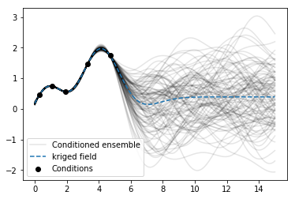

```python
model = gs.Gaussian(dim=1, var=0.5, len_scale=2)
srf = gs.SRF(model)
srf.set_condition(cond_pos, cond_val, "ordinary")
fields = []
for i in range(100):
    # print(i) if i % 10 == 0 else None
    fields.append(srf(gridx, seed=i))
    label = "Conditioned ensemble" if i == 0 else None
    plt.plot(gridx, fields[i], color="k", alpha=0.1, label=label)
plt.plot(gridx, srf.krige_field, linestyle="dashed", label="kriged field")
plt.scatter(cond_pos, cond_val, color="k", zorder=10, label="Conditions")
plt.legend()
plt.show()
```

# Tutorial 6: Field transformations

The generated fields of GSTools are ordinary Gaussian random fields. But there are several transformations to describe different real world problems in an appropriate manner.

GStools provides a submodule gstools.transform with a range of common transformations, including:

| Name | Description |
| --- | --- |
| `binary` | Binary transformation. |
| `discrete` | Discrete transformation. |
| `boxcox` | Box-Cox transformation. |
| `zinnharvey` | Zinn and Harvey transformation to connect low/high values. |
| `normal_to_lognormal` | Transform to log-normal distribution. |
| `normal_to_uniform` | Transform to uniform distribution on $[0, 1]$. |

## Example: Zinn & Harvey transformation

Here, we transform a field with the so called “Zinn & Harvey” transformation presented in *Zinn & Harvey (2003)*. With this transformation, one could overcome the restriction that in ordinary Gaussian random fields the mean values are the ones being the most connected.

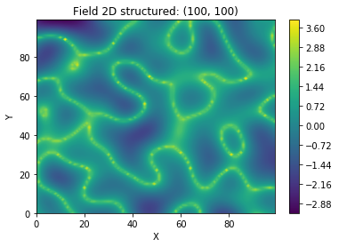

```python
x = y = range(100)
model = gs.Gaussian(dim=2, var=1, len_scale=10)
srf = gs.SRF(model, seed=20170519)
srf.structured([x, y])
gs.transform.zinnharvey(srf, conn="high")
srf.plot()
```

# Final words

This was a brief glimpse on what `GSTools` is capable of. The package is included in an infrastructure of Python packages called the **"GeoStat Framework"** (https://geostat-framework.org/), that provides multiple tools to analyze field measurements and run geo-statistical simulations.

Recently, the package `PyKrige` joined this framework and we are working on a sibling-like coexistence of both packages.

You can contact us via mail or on [Gitter](https://gitter.im/GeoStat-Framework/GSTools)

## Future

We are currently working on a publication for the `v1.2.1` release.

There are a lot of feature requests, that we target to implement:

- convenient geo-coordinate support
- n-dimensional field generation and kriging
- automated variogram estimation including anisotropy
- adaptation to `sklearn` for machine learning support

We ar planing to cooperate with the developers of `scikit-gstat`, a similar package providing fancy variography routines, that is also presented at the EGU2020 ([link](https://meetingorganizer.copernicus.org/EGU2020/EGU2020-6678.html))